# Martian Meteorology: The Dust Storm of Y34

Asa M Kaplan

2026-04-27

### Data Clean-up w/ R

Installed Packages:

```r
options(repos = c(CRAN = "https://cran.rstudio.com/"))
install.packages("tidyverse")
install.packages("readr")
install.packages("ggplot2")
library(tidyverse)
library(readr)
library(ggplot2)
```

The dataset can be obtained [here](https://www.kaggle.com/datasets/deepcontractor/mars-rover-environmental-monitoring-station)<sup>2</sup>.  
Lets view and gather basic info about the dataset.

```r
mars_weather <- read.csv("REMS_Mars_Dataset.csv")
head(mars_weather)
colnames(mars_weather)
str(mars_weather)
View(mars_weather)
```

The CSV file left some periods in place of “°” and parentheses so we need to edit some column names.

```r
mars_weather <- mars_weather %>% rename(earth_date = earth_date_time,
                                        mars_date = mars_date_time,
                                        sol = sol_number,
                                        "max_ground_temp" = max_ground_temp..C.,
                                        "min_ground_temp" =   min_ground_temp..C.,
                                        "max_air_temp" = max_air_temp..C.,
                                        "min_air_temp" = min_air_temp..C.,
                                        "mean_pressure" = mean_pressure.Pa.,
                                        "wind_speed" = wind_speed.m.h.,
                                        "humidity" = humidity...,
                                        uv_radiation = UV_Radiation,)
```

Next we clean-up the column returns, removing extra fluff that detracts from the meat of our data.  
All of the info we are removing is already iterated in the column names.  
Removing this data also facilitates future analysis.

```r
mars_weather <- mars_weather %>% mutate(earth_date = str_remove_all(earth_date, "Earth, | UTC"),
                                        mars_date = str_remove_all(mars_date,"Mars, |°"),
                                        sol = str_remove_all(sol, "Sol "))
```

As seen in our earlier str() fxn execution, all columns are returning character classifications even if their column returns are numbers. Lets change those to “numeric”.

```r
mars_weather <- mars_weather %>% mutate_at(c(3:8), as.numeric)
```

As seen in our earlier View() fxn execution, the windspeed and humidity columns are returning “NA” instead of actual measures. Similarly, the weather column is returning “sunny” for every response (probably because Curiosity was pretty close to the Martian equator).  
This absent data is unfortunate but is cluttering our dataset; let’s remove it.

```r
mars_weather <- mars_weather %>% select(-wind_speed, -humidity, -weather)
```

Using the sunrise and sunset timing included in the dataset, we can formulate a new column with the daylight time (in minutes) for each Sol.

```r
mars_weather$daylight_minutes <- as.numeric(
  difftime(strptime(mars_weather$sunset, "%H:%M"),
           strptime(mars_weather$sunrise, "%H:%M"),
           units = "mins"))
```

In that same vein, we can create a column for the averages of the ground and air temperatures using mutate() from the dplyr package.

```r
mars_weather <- mars_weather %>%
  mutate(mean_ground_temp = (max_ground_temp + min_ground_temp) / 2)
mars_weather <- mars_weather %>%
  mutate(mean_air_temp = (max_air_temp + min_air_temp) / 2)
```

Solar Longitude (Ls) is the position of the Sun as its seen from a planet (Mars in this instance).  
Ls is an accurate ways to determine a planets time position with regard to its year (one orbit around the Sun).  
In this way, Ls can be used to determine the “seasons” on Mars.  
Conveniently for us, the *mars_date* column includes the associated Ls in its outputs.

```r
mars_weather$solar_long <- str_sub(mars_weather$mars_date,-3,-1)
mars_weather <- mars_weather %>% mutate(solar_long = str_remove_all(solar_long,"S | "))
mars_weather$solar_long <- as.numeric(mars_weather$solar_long)
```

```r
mars_weather <- mars_weather %>% mutate(season = case_when(
  between(solar_long, 0, 89)~"Autumn",
  between(solar_long, 90, 179)~"Winter",
  between(solar_long, 180, 269)~"Spring",
  between(solar_long, 170, 359)~"Summer",))
mars_weather$season <-  factor(mars_weather$season, levels = c("Autumn",
                                                               "Winter",
                                                               "Spring",
                                                               "Summer"))
mars_weather$season <- factor(mars_weather$season,    #reorder the seasons into standard chronological order
                              levels = c("Autumn", "Winter", "Spring", "Summer"))
```

Following this, we will also add the Mars Years column.  
Once again, due to the eccentric, elliptical (oval) nature of Mars’ orbit, some calculations are required.  
1 Mars Year = 668.6 Sols so we would need to factor in leap years every 5 or so orbits; this wonkiness is further complicated by a lack of an agreed upon Martian calendar.  
As such, Solar Longitude (Ls) will be a much more uniform and reliable. The sols that you see referenced in the below code correspond to Ls 0 and LS 359 accordingly (aside from the incomplete years 31 & 36). In this way, we can determine our Martian Years!

```r
mars_weather <- mars_weather %>% mutate(mars_year = case_when(
  between(sol, 0, 350)~"Year 31",
  between(sol, 351, 1018)~"Year 32",
  between(sol, 1019, 1687)~"Year 33",
  between(sol, 1688, 2356)~"Year 34",
  between(sol, 2357, 3023)~"Year 35",
  between(sol, 3024, 3368)~"Year 36",))
```

Now that we have completed our janitorial duties, we will use the write.csv() fxn to export our cleaned dataset

```r
write.csv(mars_weather, file = "mars_weather_clean.csv", row.names = FALSE)
# exporting to CSV makes this an accessible file for use with a variety of programs, however, we then have to execute a factor() fxn on the seasonal order every time we load it again
saveRDS(mars_weather, "mars_weather_clean.rds")
# exporting to RDS makes this solely usable through R, however, it means we don't have to refactor for the proper season order every time
```

### Data Visualizations

First and foremost, we need to exclude Year 31 and Year 36 from the dataset analyses as these are ‘incomplete’ data years, only having about 350 sols of data respectively (only about 1/2 of a full Martian year).

```r
mars_weather <- readRDS("mars_weather_clean.rds") # load the RDS file for visualizations
# FOR CSV: mars_weather <- read_csv("mars_weather_clean.csv")
# IF CSV IS USED: reminder that factor() will need to be run again to reorder the seasons (code below)
#   mars_weather$season <- factor(mars_weather$season, levels = c("Autumn", "Winter", "Spring", "Summer"))
# IF RDS IS USED: no factor() is necessary
mars_season <- mars_weather %>% filter(mars_year != "Year 31", mars_year != "Year 36")
```

Now that we have years 32, 33, 34, and 35 isolated, we can start our visualizations

#### Daylight Variations

We can begin by looking at the data from a column we created earlier–the daylight_minutes column  
The pattern here is a clear increase/decrease associated with what we experience our days like on earth: a steady increase of sunlight from the start of Winter to the end of Spring and a steady decrease of sunlight from the start of Summer to the end of Autumn

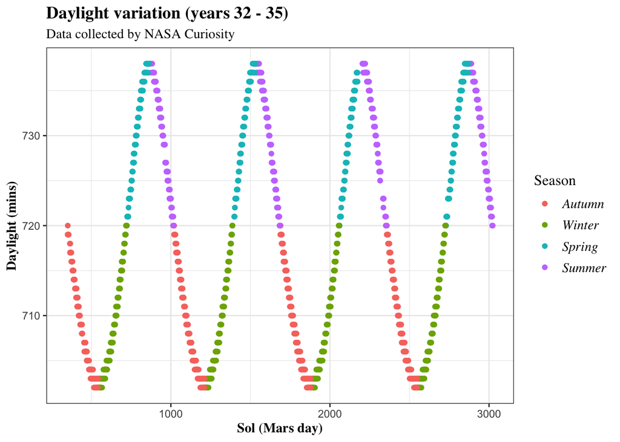

```r
ggplot(mars_season) +
  (aes(x = sol,  y = daylight_minutes)) +
  geom_point(aes(color = season)) + theme_bw() +
  theme(plot.title = element_text(family = "serif", size = 14, face = "bold"),
        plot.subtitle = element_text(family = "serif", size = 11),
        axis.title.x = element_text(family = "serif", size = 11, face = "bold"),
        axis.title.y = element_text(family = "serif", size = 11, face = "bold"),
        legend.title = element_text(family = "serif", size = 12),
        legend.text = element_text(family = "serif", size = 11, face = "italic")) +
  labs(title="Daylight variation (years 32 - 35)",
       subtitle = "Data collected by NASA Curiosity",
       x ="Sol (Mars day)", y = "Daylight (mins)",
       color = "Season")
```

#### Air Temperature Variations

This viz shows the upper and lower limits of the *air* temperatures across the seasons. As expected there is general consistency of annual heating and cooling, reflective of the planets tilt and resulting seasons. However, keen eyes will immediately note the outlier concentrations during Year 34.  
Further information will give context to these outliers so keep them in mind as we continue.

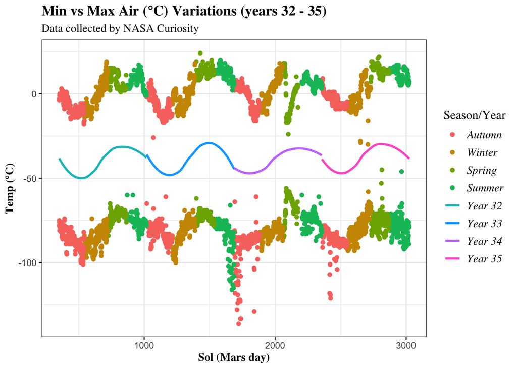

```r
ggplot(mars_season) +
  geom_point(aes(x = sol, y = max_air_temp, color = season)) +
  geom_point(aes(x = sol, y = min_air_temp, color = season)) +
  geom_smooth(se = FALSE, aes(x = sol, y = mean_air_temp, color = mars_year)) +
  theme_bw() +
  theme(plot.title = element_text(family = "serif", size = 14, face = "bold"),
        plot.subtitle = element_text(family = "serif", size = 11),
        axis.title.x = element_text(family = "serif", size = 11, face = "bold"),
        axis.title.y = element_text(family = "serif", size = 11, face = "bold"),
        legend.title = element_text(family = "serif", size = 12),
        legend.text = element_text(family = "serif", size = 11, face = "italic")) +
  labs(title="Min vs Max Air (°C) Variations (years 32 - 35)",
       subtitle = "Data collected by NASA Curiosity",
       x ="Sol (Mars day)", y = "Temp (°C)",
       color = "Season/Year")
```

#### Ground Temperature Variations

This viz shows the upper and lower limits of the *ground* temperature across the seasons. The heating and cooling, once again, aptly reflects the expected seasonal changes. Again, however, we do see that significant trend towards homogeneity in Year 34 that is not seen in any other year.

Interestingly enough, though, the notable drops in minimum air temperatures observed in Y33 late Summer and Y34 early Autumn are absent in minimum ground temps of the same time. It is likely that the this can be explained by the grounds natural tendency towards thermal equilibrium (and its ability to retain heat better than the air).

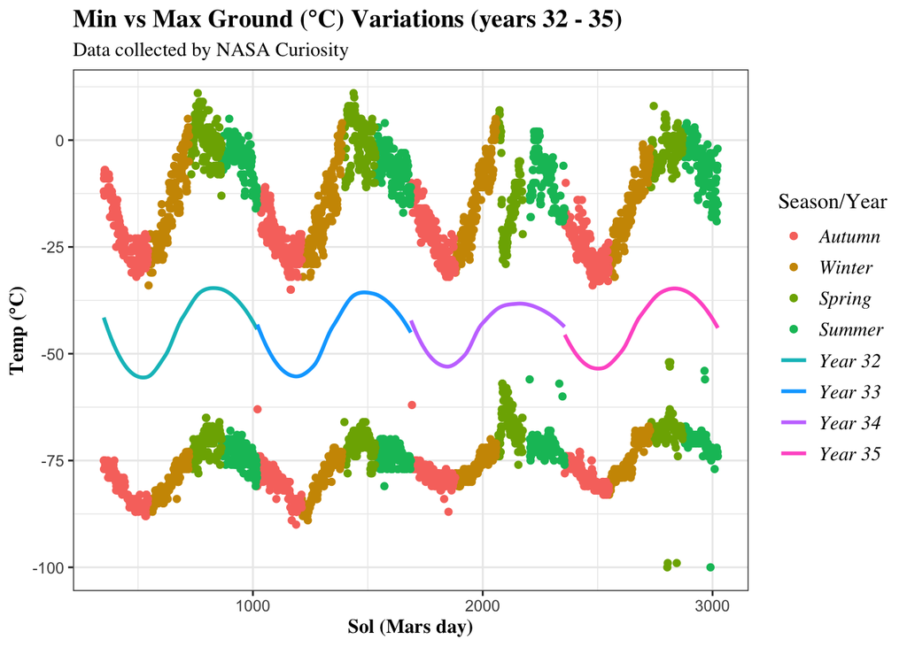

```r
ggplot(mars_season) +
  geom_point(aes(x = sol, y = max_ground_temp, color = season)) +
  geom_point(aes(x = sol, y = min_ground_temp, color = season)) +
  geom_smooth(se = FALSE, aes(x = sol, y = mean_ground_temp, color = mars_year)) +
  theme_bw() +
  theme(plot.title = element_text(family = "serif", size = 14, face = "bold"),
        plot.subtitle = element_text(family = "serif", size = 11),
        axis.title.x = element_text(family = "serif", size = 11, face = "bold"),
        axis.title.y = element_text(family = "serif", size = 11, face = "bold"),
        legend.title = element_text(family = "serif", size = 12),
        legend.text = element_text(family = "serif", size = 11, face = "italic")) +
  labs(title="Min vs Max Ground (°C) Variations (years 32 - 35)",
       subtitle = "Data collected by NASA Curiosity",
       x ="Sol (Mars day)", y = "Temp (°C)",
       color = "Season/Year")
```

In the following section we will hone in on Year 34 and, with some external research, will conclude the variable that influence the trend towards homogeneous ground and air temperatures in Year 34 Spring.

### THE DUSTSTORM

#### Mars Year 34

First, lets take a zoomed in view of our Year 34 temperature data  
Lets start by isolating Year 34 from our full dataset

```r
year34_mars <- mars_weather %>% filter(mars_year == "Year 34")
```

Next, lets look at some visualizations

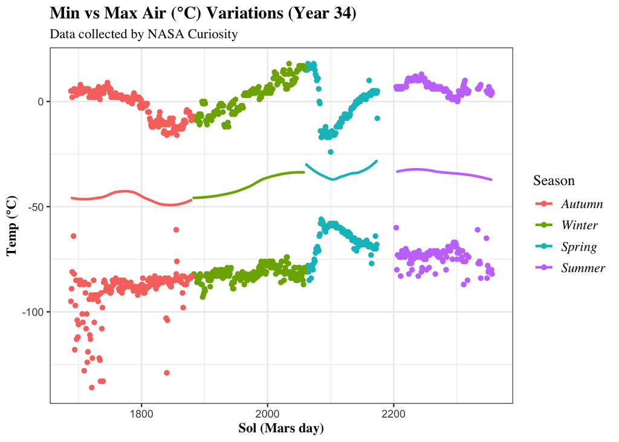

```r
ggplot(year34_mars) +
  theme_bw() +
  geom_smooth(se = FALSE, aes( x = sol, y = mean_air_temp, color = season)) +
  geom_point(aes(x = sol, y = max_air_temp, color = season)) +
  geom_point(aes(x = sol, y = min_air_temp, color = season)) +
  theme(plot.title = element_text(family = "serif", size = 14, face = "bold"),
        plot.subtitle = element_text(family = "serif", size = 11),
        axis.title.x = element_text(family = "serif", size = 11, face = "bold"),
        axis.title.y = element_text(family = "serif", size = 11, face = "bold"),
        legend.title = element_text(family = "serif", size = 12),
        legend.text = element_text(family = "serif", size = 11, face = "italic")) +
  labs(title = "Min vs Max Air (°C) Variations (Year 34)",
       subtitle = "Data collected by NASA Curiosity",
       x = "Sol (Mars day)",
       y = "Temp (°C)",
       color = "Season")
```

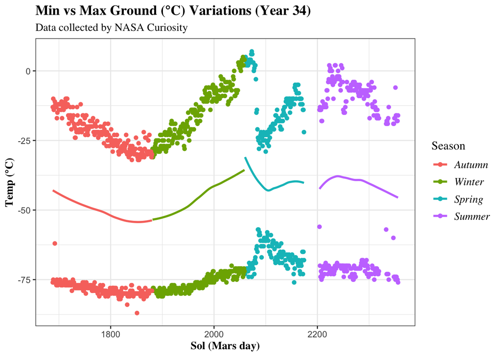

```r
ggplot(year34_mars) +
  theme_bw() +
  geom_smooth(se = FALSE, aes( x = sol, y = mean_ground_temp, color = season)) +
  geom_point(aes(x = sol, y = max_ground_temp, color = season)) +
  geom_point(aes(x = sol, y = min_ground_temp, color = season)) +
  theme(plot.title = element_text(family = "serif", size = 14, face = "bold"),
        plot.subtitle = element_text(family = "serif", size = 11),
        axis.title.x = element_text(family = "serif", size = 11, face = "bold"),
        axis.title.y = element_text(family = "serif", size = 11, face = "bold"),
        legend.title = element_text(family = "serif", size = 12),
        legend.text = element_text(family = "serif", size = 11, face = "italic")) +
  labs(title = "Min vs Max Ground (°C) Variations (Year 34)",
       subtitle = "Data collected by NASA Curiosity",
       x = "Sol (Mars day)",
       y = "Temp (°C)",
       color = "Season")
```

A trend toward thermal homogeneity within a time-span that historically retains consistent temperature variation implies that something was likely impeding that which causes those fluctuations. In this case, because there is no possibility for an artificial impact on temperature on a barren planet such as Mars, we must defer to natural sources of heat, namely the Sun and geological processes like volcanic eruptions.

We can eliminate volcanic eruptions as the cause here as, if eruptions of heat onto the surface were the source, we would see a major increase in maximum temperatures, not the decrease that is present. As such, we narrow our focus to the Sun and the variable negating its transference of heat. Something is keeping temperature from increasing, yet is simultaneously keeping heat from leaving. Again noting a distinct lack of artificial impacts and following our logic-path of purely natural factors at play, we find our culprit: Martian dust.

Dust storms are not unfamiliar to us earth-dwellers and are even a familiar occurrence to those living and/or operating in dry climates such as the Sahara in Africa, the Gobi Desert in East Asia, and the Arabian peninsula. Perhaps, then, it is no surprise that a vastly arid planet such as Mars would also experience frequent dust storms.

A [NASA article](https://science.nasa.gov/solar-system/10-things-dust-in-the-wind-on-mars-and-well-beyond/) on dust notes that these Martian dust storms are particularly prevalent during the Southern Hemispheres Spring and Summer. This is expected as this is when Mars is closest to the Sun in its elliptical orbit. This intensifies the heat on Mars significantly and, as a result, the winds increase as well, kicking up dust particles and directly leading to the formation of dust devils and, on a larger scale, dust storms.

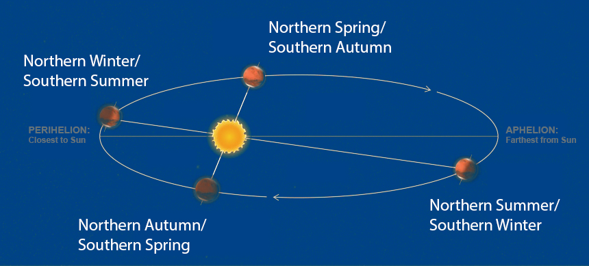

[source](https://science.nasa.gov/resource/seasons-in-the-martian-year-as-the-red-planet-orbits-the-sun/)<sup>7</sup>

These dust storms can act as insulators, impeding a majority of the sunlight from reaching the ground while simultaneously blocking the thermal energy that does make it through from leaving the Martian area. This dust-fueled insulation precisely explains the trend towards thermal homogeneity that we see during that Y34 Spring. Mars Year 34 (in reference to the April 11, 1955 start-date<sup>8</sup>) on Mars equates to May 5, 2017 to March 22, 2019. This overlaps directly with the 2018 dust-storm that [NASA reported](https://mars.nasa.gov/weather/storm-watch-2018/) had buried their Opportunity rover. This dust storm is magnificent with regard to its global scale, encompassing nearly the entirety of Mars in a chaotic mass of dancing Martian dust particles. Phenomena like this would be unbelievably catastrophic for Earth, yet is a common and entirely natural part of the Martian abiotic environment.

##### TL;DR

- The trend towards homogeneity within the Martian year 34 Spring season is a result of a global dust storm that insulated the planet
- This stopped sunlight from reaching the Martian surface and trapping existing heat within the Martian atmosphere
- As a result, the expected temperature flux b/t max and min temperatures is lower than other observed years

#### Sources

1. Posit Software, PBC. (2023). *RStudio* (Version 2023.XX.X) [Computer software]. https://posit.co/download/rstudio-desktop/
2. Deep Contractor. (2022). *Mars rover environmental monitoring station* [Data set]. Kaggle. https://www.kaggle.com/datasets/deepcontractor/mars-rover-environmental-monitoring-station
3. Gómez-Elvira, J., et al. (2014). *Mars Science Laboratory Rover Environmental Monitoring Station (REMS) data set.* NASA Planetary Data System.
4. National Aeronautics and Space Administration. (n.d.). *Mars Science Laboratory (Curiosity)*. NASA Science. https://science.nasa.gov/mission/msl-curiosity/
5. National Aeronautics and Space Administration. (2022, July 26). *10 things: Dust in the wind (on Mars and well beyond)*. NASA Science. https://science.nasa.gov/solar-system/10-things-dust-in-the-wind-on-mars-and-well-beyond/
6. National Aeronautics and Space Administration. (2018). *Mars storm watch: 2018 dust storm*. NASA. https://mars.nasa.gov/weather/storm-watch-2018/
7. National Aeronautics and Space Administration. (2016, July 1). *Seasons in the Martian year as the Red Planet orbits the Sun. NASA Science*. https://science.nasa.gov/resource/seasons-in-the-martian-year-as-the-red-planet-orbits-the-sun/
8. Clancy, R. T., Sandor, B. J., Wolff, M. J., Christensen, P. R., Smith, M. D., Pearl, J. C., Conrath, B. J., & Wilson, R. J. (2000). *An intercomparison of ground-based millimeter, MGS TES, and Viking atmospheric temperature measurements: Seasonal and interannual variability of temperatures and dust loading in the global Mars atmosphere*. Journal of Geophysical Research: Planets, 105(E4), 9553–9571. https://doi.org/10.1029/1999JE001089

Thank you for reading! I am an aspiring data analyst and this is just a first attempt at documenting my process. Any and all comments are welcome!